# Teacher Focus Group Survey

#### **State Reading Test Score**

##### **Which line might better correspond with the SBAC performance level?**

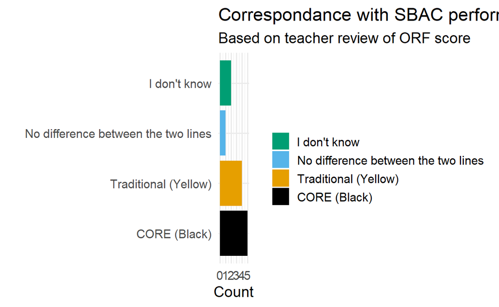

##### **Based on the last data point from *May or June* ONLY, which point might better match what you expect from a student at this SBAC performance level?**

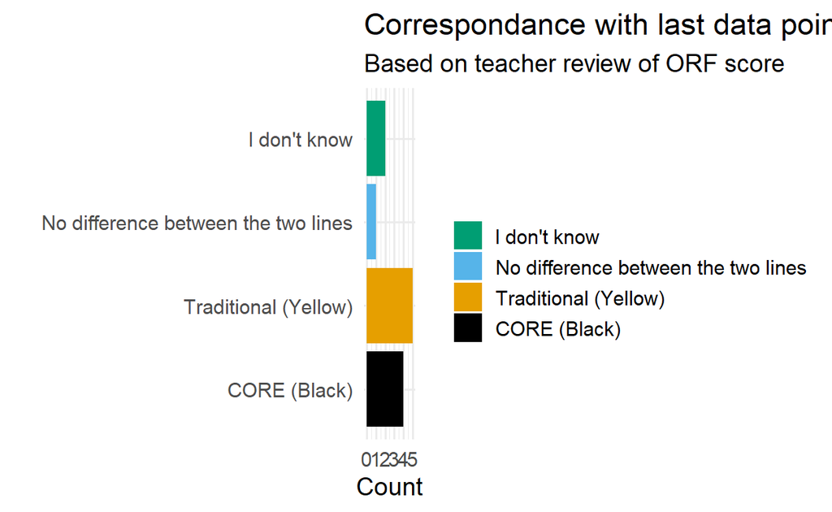

##### **Based on the first data point from *October or November* ONLY, which point might better match what you expect from a student at this SBAC performance level?**

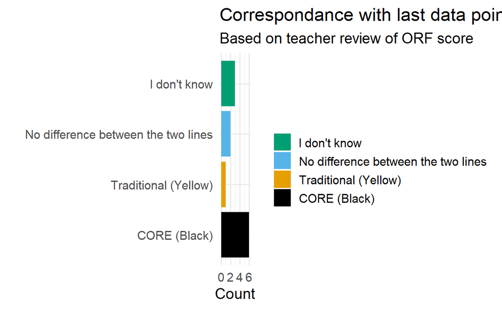

**Results:** Although it was close, more teachers agreed that the black (CORE) line corresponds better with the SBAC performance level. Based on the first data point from October or November only, most teachers agreed that the black (CORE) line is a better match for the student’s expected SBAC performance level. However, when looking only at the last data point from May or June only, more teachers agreed that the yellow line was a better comparison.

### **Student Figures with Measurement Error**

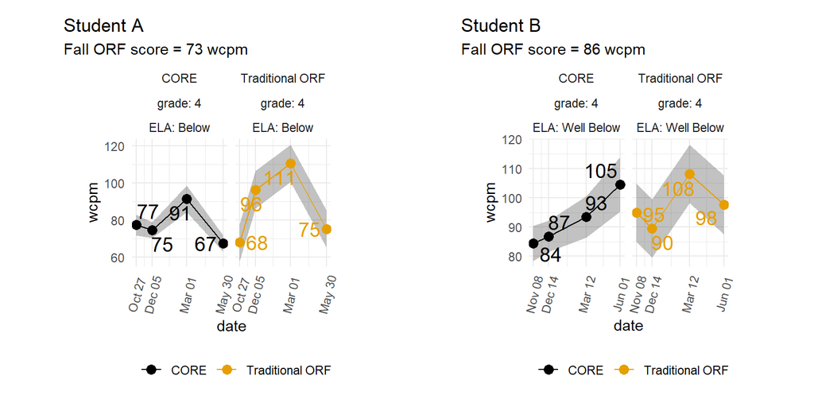

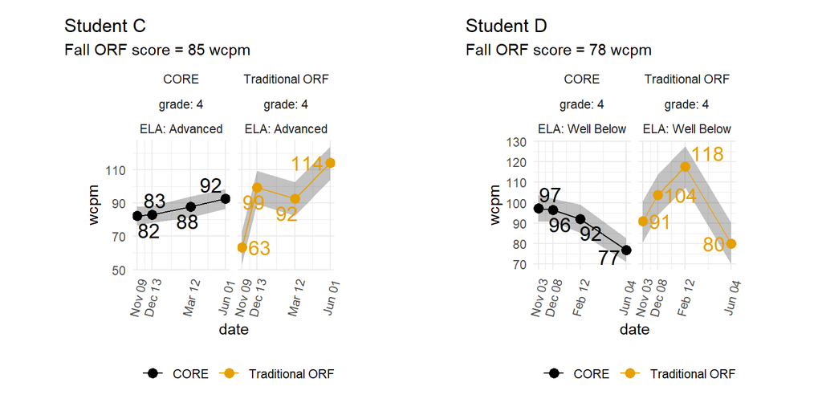

#### **Progress Monitoring and Data-Based Decisions**

##### **Which line might be better for progress monitoring and data-based decisions?**

[output not shown]

**Results:** Teachers almost unanimously agreed that the black (CORE) line was better for progress monitoring and data-based decisions. Many noted that it appeared to have a smaller measurement error and more consistent trend.

#### **Measurement Error Useful?**

##### **Does the shaded area in the graphs give you useful information if you were using the graphs to make data-based decisions?**

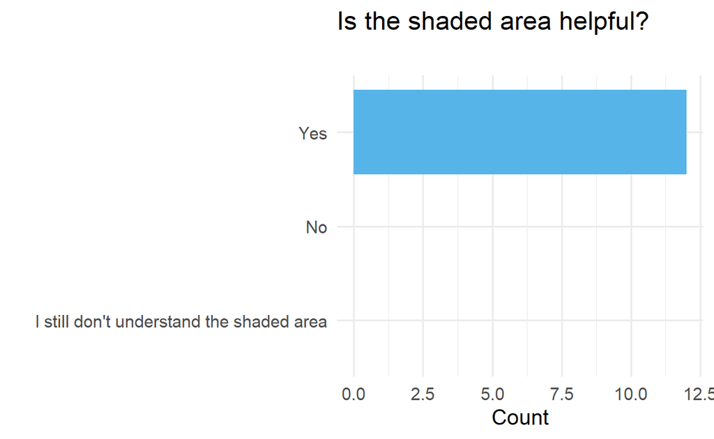

#### **How might you use this figure to make a data-based decision?**

[output not shown]

**Results:** Teachers unanimously agreed that the shaded area was helpful to consider when making data-based decisions. Many noted that it increased the reliability of the data overall and allowed them to evaluate whether their interventions were effective or not.